# Latihan Pertemuan 4

# PROSES MA(2)

## Bangkitkan data MA(2)

Model MA(2) yang digunakan adalah:

$$Y_t = \varepsilon_t + \theta_1\varepsilon_{t-1} +
\theta_2\varepsilon_{t-2}$$
dengan:

$$\theta_1 = 0.4,\qquad \theta_2 = 0.6$$
Jumlah data yang dibangkitkan adalah 300 data.

### Manual

```r
set.seed(123)

n <- 300
theta1 <- 0.4
theta2 <- 0.6

epsilon <- rnorm(n + 2, mean = 0, sd = 1)
```

```r
Y_manual <- numeric(n)

for (t in 3:(n + 2)) {
  Y_manual[t - 2] <- epsilon[t] +
    theta1 * epsilon[t - 1] +
    theta2 * epsilon[t - 2]
}

head(Y_manual)
```

```
## [1]  1.13035193  0.55588522  1.09271608  1.80908512  1.22451484 -0.05165576
```

### arima.sim

```r
set.seed(123)

Y_arima <- arima.sim(
  model = list(ma = c(theta1, theta2)),
  n = 300
)

head(Y_arima)
```

```
## Time Series:
## Start = 1
## End = 6
## Frequency = 1
## [1]  1.13035193  0.55588522  1.09271608  1.80908512  1.22451484 -0.05165576
```

### Membandingkan Data

```r
data.frame(
  Manual = head(Y_manual, 10),
  ARIMA_sim = head(Y_arima, 10)
)
```

```
##         Manual   ARIMA_sim
## 1   1.13035193  1.13035193
## 2   0.55588522  0.55588522
## 3   1.09271608  1.09271608
## 4   1.80908512  1.80908512
## 5   1.22451484  1.22451484
## 6  -0.05165576 -0.05165576
## 7  -0.91632762 -0.91632762
## 8  -1.47943985 -1.47943985
## 9   0.63370530  0.63370530
## 10  0.58204936  0.58204936
```

## Plot Time Series

### Data Manual

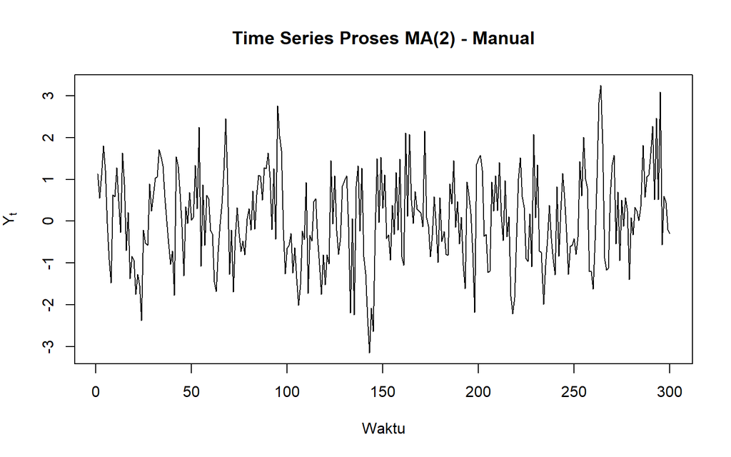

```r
plot(
  ts(Y_manual),
  main = "Time Series Proses MA(2) - Manual",
  xlab = "Waktu",
  ylab = expression(Y[t]),
  type = "l"
)
```

### Data arima.sim

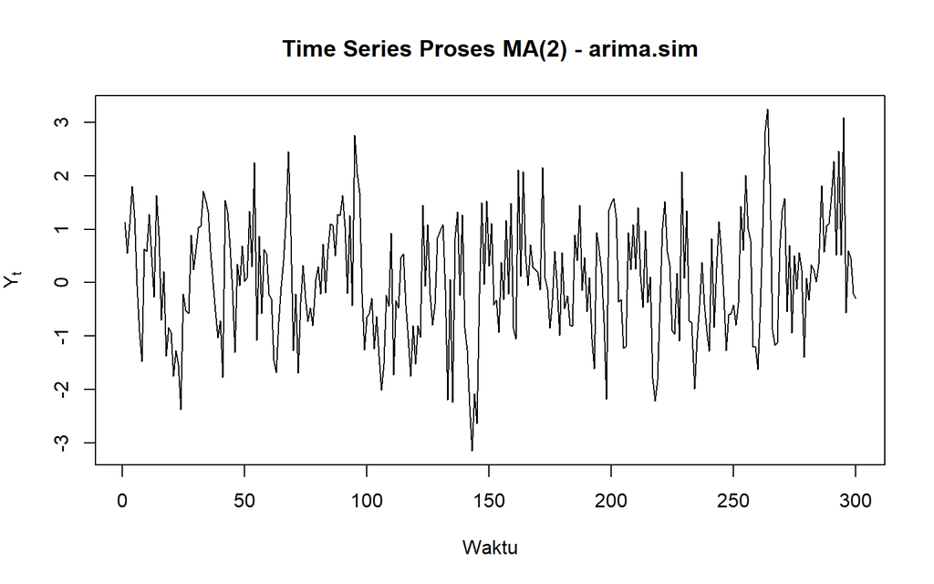

```r
plot(
  ts(Y_arima),
  main = "Time Series Proses MA(2) - arima.sim",
  xlab = "Waktu",
  ylab = expression(Y[t]),
  type = "l"
)
```

## PLot ACF

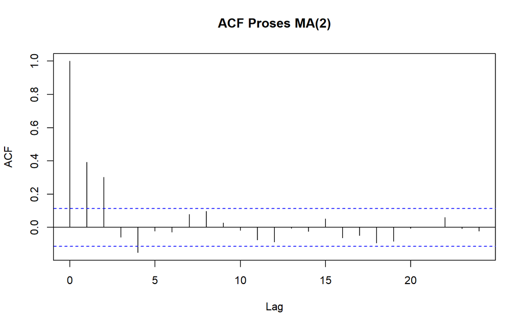

```r
acf(
  Y_arima,
  main = "ACF Proses MA(2)"
)
```

## Plot PACF

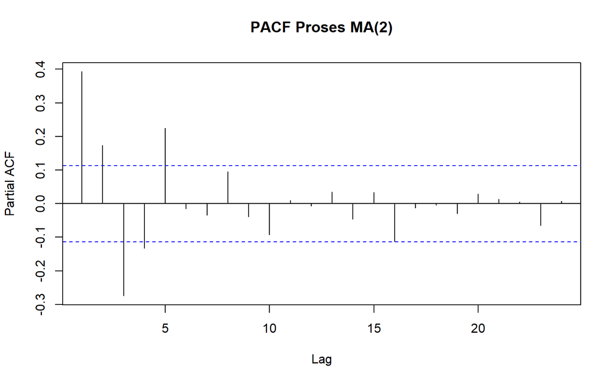

```r
pacf(
  Y_arima,
  main = "PACF Proses MA(2)"
)
```

## Plot EACF

```r
library(TSA)
```

```r
eacf(Y_arima)
```

```
## AR/MA
##   0 1 2 3 4 5 6 7 8 9 10 11 12 13
## 0 x x o x o o o o o o o  o  o  o
## 1 x x x x o o o o o o o  o  o  o
## 2 x x o x o o o o o o o  o  o  o
## 3 x x o o x o o o o o o  o  o  o
## 4 x x x x x o o o o o o  o  o  o
## 5 o x x x x o o o o o o  o  o  o
## 6 x o x x o o o o o o o  o  o  o
## 7 x x o x x o o o o o o  o  o  o
```

## Identifikasi Stasioneritas

Untuk melihat kestasioneran secara visual:

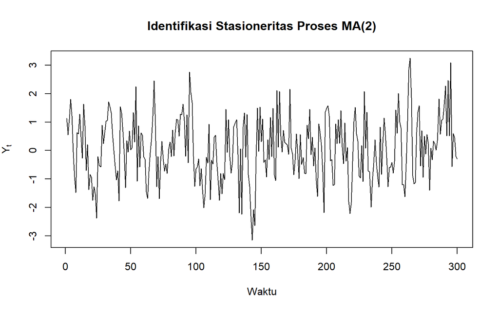

```r
plot(
  ts(Y_arima),
  main = "Identifikasi Stasioneritas Proses MA(2)",
  xlab = "Waktu",
  ylab = expression(Y[t]),
  type = "l"
)
```

Uji ADF

```r
library(tseries)
adf.test(Y_arima)
```

```
##
##  Augmented Dickey-Fuller Test
##
## data:  Y_arima
## Dickey-Fuller = -6.0966, Lag order = 6, p-value = 0.01
## alternative hypothesis: stationary
```

Berdasarkan visual dan uji yang kita lakukan, dapat disimpulkan bahwa datanya stasioner.

## Scatter PLot

### Scatterplot $Y_t$ dengan $Y_{t-1}$

Membentuk data lag 1:

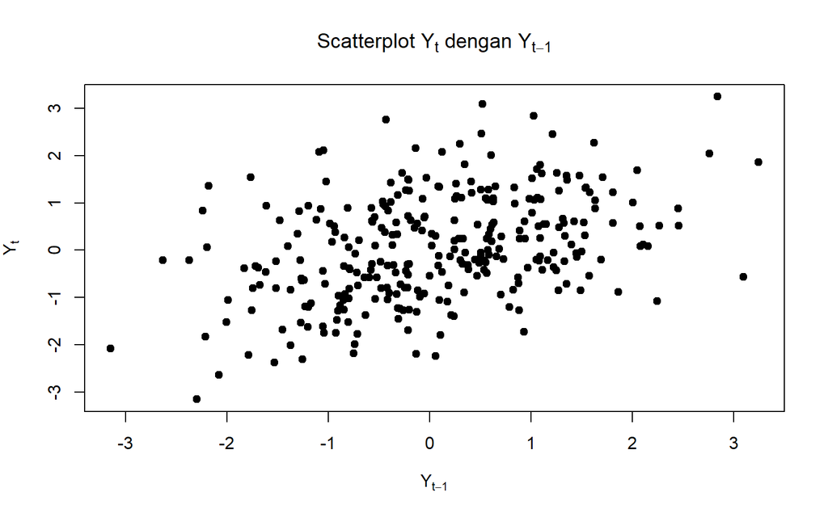

```r
lag1 <- data.frame(
  Yt = Y_arima[2:300],
  Yt_1 = Y_arima[1:299]
)

plot(
  lag1$Yt_1,
  lag1$Yt,
  main = expression(paste("Scatterplot ", Y[t], " dengan ", Y[t-1])),
  xlab = expression(Y[t-1]),
  ylab = expression(Y[t]),
  pch = 19
)
```

### Scatterplot $Y_t$ dengan $Y_{t-2}$

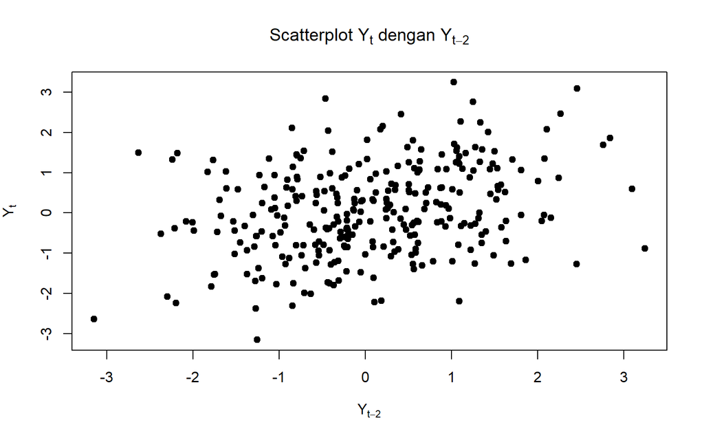

```r
lag2 <- data.frame(
  Yt = Y_arima[3:300],
  Yt_2 = Y_arima[1:298]
)

plot(
  lag2$Yt_2,
  lag2$Yt,
  main = expression(paste("Scatterplot ", Y[t], " dengan ", Y[t-2])),
  xlab = expression(Y[t-2]),
  ylab = expression(Y[t]),
  pch = 19
)
```

### Scatterplot $Y_t$ dengan $Y_{t-3}$

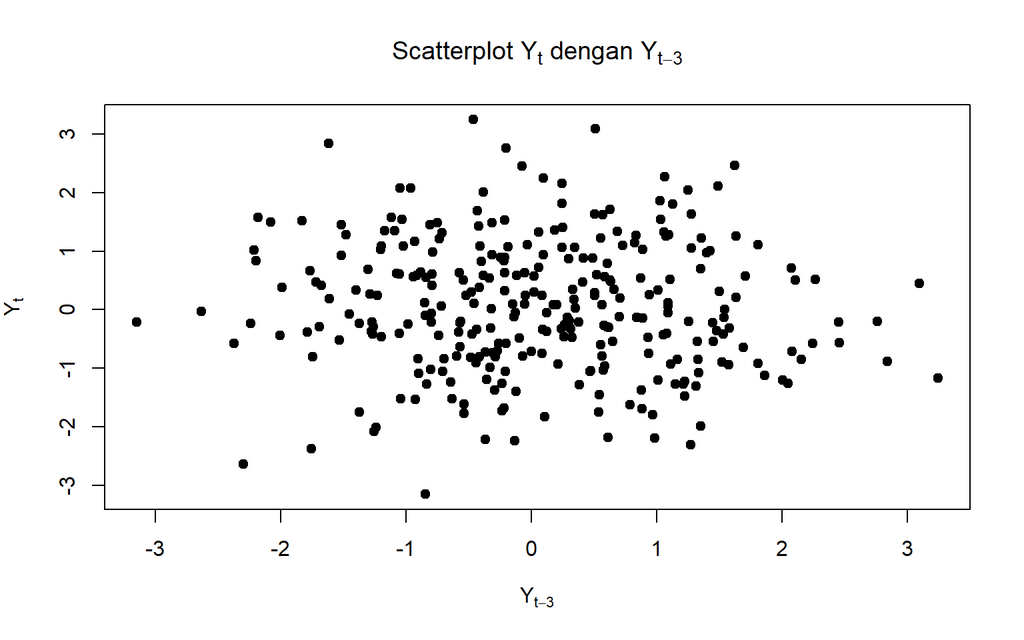

```r
lag3 <- data.frame(
  Yt = Y_arima[4:300],
  Yt_3 = Y_arima[1:297]
)

plot(
  lag3$Yt_3,
  lag3$Yt,
  main = expression(paste("Scatterplot ", Y[t], " dengan ", Y[t-3])),
  xlab = expression(Y[t-3]),
  ylab = expression(Y[t]),
  pch = 19
)
```

## Autokorelasi

### Autokorelasi Data Bangkitan

```r
acf_result <- acf(
  Y_arima,
  plot = FALSE
)

acf_result$acf
```

```
## , , 1
##
##               [,1]
##  [1,]  0.392913323
##  [2,]  0.301493336
##  [3,] -0.058717397
##  [4,] -0.151296834
##  [5,] -0.021069442
##  [6,] -0.028328470
##  [7,]  0.078665219
##  [8,]  0.097192326
##  [9,]  0.028365033
## [10,] -0.017419077
## [11,] -0.075933854
## [12,] -0.087072213
## [13,] -0.004998512
## [14,] -0.024779359
## [15,]  0.052751691
## [16,] -0.062805887
## [17,] -0.047577890
## [18,] -0.094286412
## [19,] -0.083908976
## [20,] -0.005395731
## [21,]  0.002242552
## [22,]  0.059509947
## [23,] -0.006584078
## [24,] -0.021189162
```

```r
acf_lag <- acf(
  Y_arima,
  lag.max = 3,
  plot = FALSE
)

acf_empiris <- as.numeric(acf_lag$acf)

hasil_acf <- data.frame(
  Lag = 0:(length(acf_empiris)-1),
  Autokorelasi = acf_empiris
)

hasil_acf
```

```
##   Lag Autokorelasi
## 1   0    0.3929133
## 2   1    0.3014933
## 3   2   -0.0587174
```

### Autokorelasi Teoritis MA(2)

Untuk proses MA(2):
$$Y_t = \varepsilon_t + \theta_1\varepsilon_{t-1}
+ \theta_2\varepsilon_{t-2}$$

Autokorelasi teoritis untuk lag 1 adalah:
$$\rho_1 =
\frac{\theta_1(1+\theta_2)}
{1+\theta_1^2+\theta_2^2}$$

Sedangkan untuk lag 2:
$$\rho_2 =
\frac{\theta_2}
{1+\theta_1^2+\theta_2^2}$$

```r
theta1 <- 0.4
theta2 <- 0.6

denominator <- 1 + theta1^2 + theta2^2

rho0 <- 1
rho1 <- theta1 * (1 + theta2) / denominator
rho2 <- theta2 / denominator
rho3 <- 0

rho0
```

```
## [1] 1
```

```r
rho1
```

```
## [1] 0.4210526
```

```r
rho2
```

```
## [1] 0.3947368
```

```r
rho3
```

```
## [1] 0
```

```r
acf_teoritis <- data.frame(
  Lag = 0:3,
  Autokorelasi = c(rho0, rho1, rho2, rho3)
)

acf_teoritis
```

```
##   Lag Autokorelasi
## 1   0    1.0000000
## 2   1    0.4210526
## 3   2    0.3947368
## 4   3    0.0000000
```

### Perbandingan Autokorelasi Empiris dan Teoritis

```r
acf_empiris <- as.numeric(
  acf(Y_arima, lag.max = 3, plot = FALSE)$acf
)

acf_empiris <- acf_empiris[1:4]

perbandingan <- data.frame(
  Lag = 0:3,
  Empiris = acf_empiris,
  Teoritis = c(rho0, rho1, rho2, rho3)
)

perbandingan
```

```
##   Lag    Empiris  Teoritis
## 1   0  0.3929133 1.0000000
## 2   1  0.3014933 0.4210526
## 3   2 -0.0587174 0.3947368
## 4   3         NA 0.0000000
```

## Kesimpulan

Berdasarkan proses MA(2) dengan $\theta_1=0.4$ dan $\theta_2=0.6$, dapat diketahui bahwa proses MA(2) bersifat stasioner. Hal ini terlihat dari pola time series yang berfluktuasi di sekitar nilai rata-rata yang relatif konstan.

Berdasarkan plot ACF, autokorelasi teoritis pada proses MA(2) akan terputus setelah lag ke-2. Dengan demikian, autokorelasi pada lag lebih dari 2 secara teoritis bernilai nol.

Nilai autokorelasi teoritis yang diperoleh adalah:

$$\rho_1 =
\frac{0.4(1+0.6)}
{1+0.4^2+0.6^2}
= 0.4211$$

dan

$$\rho_2 =
\frac{0.6}
{1+0.4^2+0.6^2}
= 0.3947$$
Sedangkan:

$$\rho_k=0,\qquad k>2.$$

Perbedaan antara autokorelasi empiris dan teoritis dapat terjadi karena data yang digunakan merupakan hasil pembangkitan sampel sebanyak 300 pengamatan, sehingga nilai empiris tidak harus persis sama dengan nilai teoritis.

# PROSES AR(2)

## Bangkitkan Data

Model AR(2) yang digunakan adalah:
$$Y_t = \phi_1Y_{t-1}+\phi_2Y_{t-2}+\varepsilon_t$$

dengan:
$$\phi_1=0.5,\qquad \phi_2=0.2$$
dan jumlah data sebanyak 300 pengamatan.

### Manual

```r
set.seed(123)

n <- 300
phi1 <- 0.5
phi2 <- 0.2
burn <- 100

epsilon <- rnorm(n + burn)

Y_full <- numeric(n + burn)

Y_full[1] <- epsilon[1]
Y_full[2] <- phi1 * Y_full[1] + epsilon[2]

for (t in 3:(n + burn)) {
  Y_full[t] <- phi1 * Y_full[t-1] +
    phi2 * Y_full[t-2] +
    epsilon[t]
}

Y_manual <- Y_full[(burn + 1):(burn + n)]

head(Y_manual)
```

```
## [1] -0.09430399  0.30919066 -0.11095735 -0.34118314 -1.14440161 -0.68546516
```

## arima.sim

```r
set.seed(123)

Y_arima <- arima.sim(
  model = list(ar = c(phi1, phi2)),
  n = 300
)

head(Y_arima)
```

```
## Time Series:
## Start = 1
## End = 6
## Frequency = 1
## [1] -2.9518714 -1.0047928 -0.9393975 -1.8087943  0.1615383  0.1454745
```

## Plot Time Series

### Data Manual

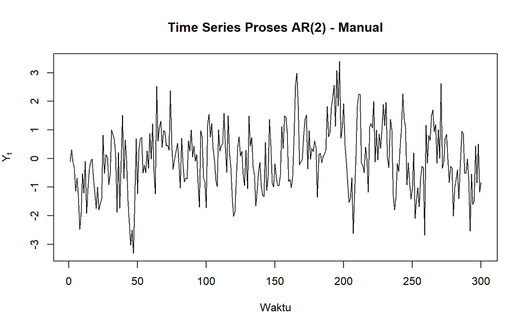

```r
plot(
  ts(Y_manual),
  main = "Time Series Proses AR(2) - Manual",
  xlab = "Waktu",
  ylab = expression(Y[t]),
  type = "l"
)
```

## Data arima.sim

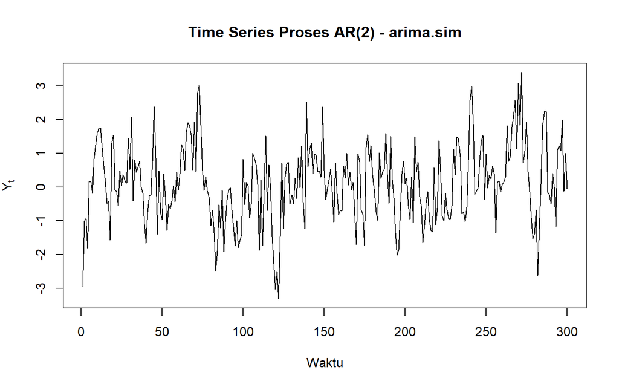

```r
plot(
  ts(Y_arima),
  main = "Time Series Proses AR(2) - arima.sim",
  xlab = "Waktu",
  ylab = expression(Y[t]),
  type = "l"
)
```

### Plot ACF

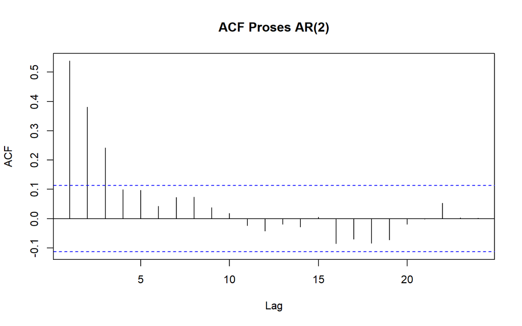

```r
acf(
  Y_arima,
  main = "ACF Proses AR(2)"
)
```

### Plot PACF

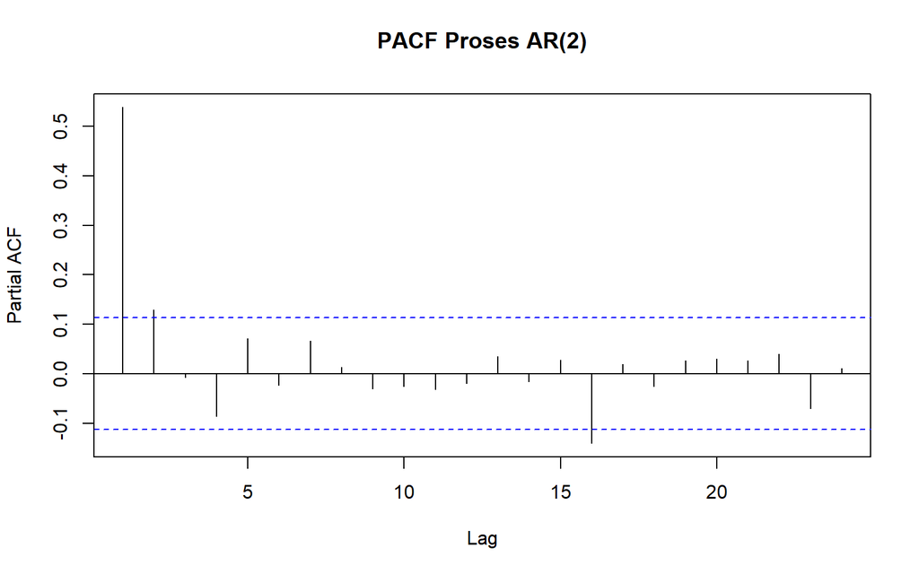

```r
pacf(
  Y_arima,
  main = "PACF Proses AR(2)"
)
```

### Plot EACF

```r
eacf(Y_arima)
```

```
## AR/MA
##   0 1 2 3 4 5 6 7 8 9 10 11 12 13
## 0 x x x o o o o o o o o  o  o  o
## 1 x o o x o o o o o o o  o  o  o
## 2 o o o o o o o o o o o  o  o  o
## 3 o x o o o o o o o o o  o  o  o
## 4 x x o o o x o o o o o  o  o  o
## 5 x x o x o o o o o o o  o  o  o
## 6 x x o x x o o o o o o  o  o  o
## 7 x x x x x o o o o o o  o  o  o
```

## Identifikasi Stasioneritas

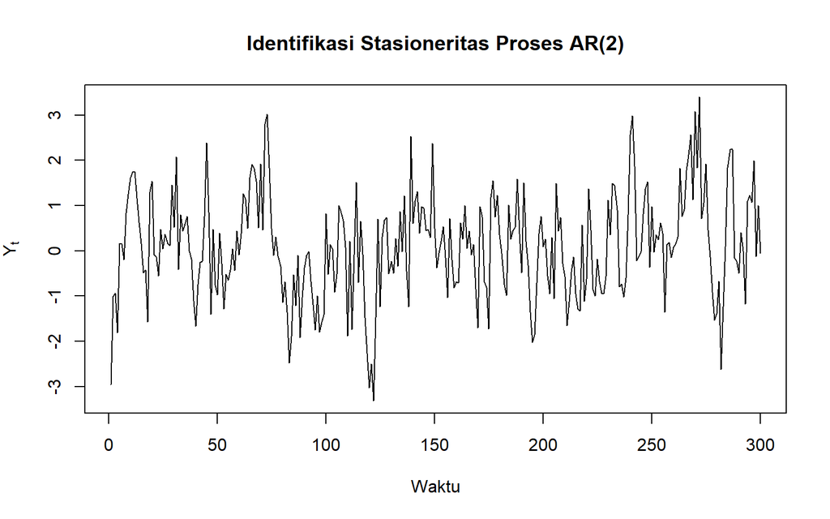

```r
plot(
  ts(Y_arima),
  main = "Identifikasi Stasioneritas Proses AR(2)",
  xlab = "Waktu",
  ylab = expression(Y[t]),
  type = "l"
)
```

```r
adf.test(Y_arima)
```

```
##
##  Augmented Dickey-Fuller Test
##
## data:  Y_arima
## Dickey-Fuller = -5.0456, Lag order = 6, p-value = 0.01
## alternative hypothesis: stationary
```

Berdasarkan visual dan uji yang kita lakukan, dapat disimpulkan bahwa datanya stasioner.

## Scatter Plot

### Scatterplot $Y_t$ dengan $Y_{t-1}$

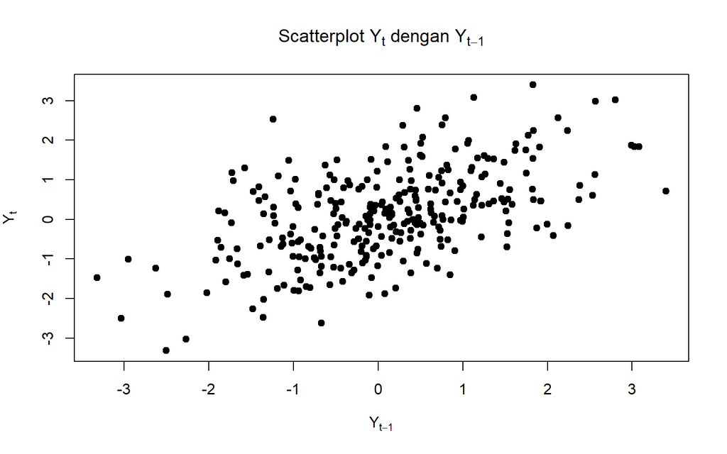

```r
lag1 <- data.frame(
  Yt = Y_arima[2:300],
  Yt_1 = Y_arima[1:299]
)

plot(
  lag1$Yt_1,
  lag1$Yt,
  main = expression(paste("Scatterplot ", Y[t], " dengan ", Y[t-1])),
  xlab = expression(Y[t-1]),
  ylab = expression(Y[t]),
  pch = 19
)
```

### Scatterplot $Y_t$ dengan $Y_{t-2}$

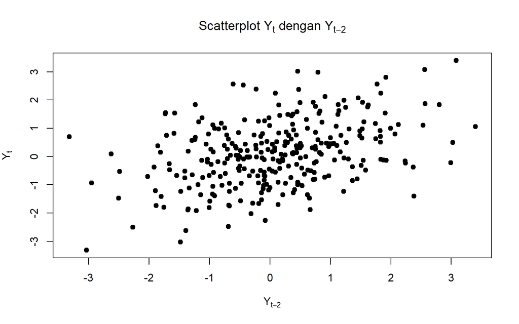

```r
lag2 <- data.frame(
  Yt = Y_arima[3:300],
  Yt_2 = Y_arima[1:298]
)

plot(
  lag2$Yt_2,
  lag2$Yt,
  main = expression(paste("Scatterplot ", Y[t], " dengan ", Y[t-2])),
  xlab = expression(Y[t-2]),
  ylab = expression(Y[t]),
  pch = 19
)
```

### Scatterplot $Y_t$ dengan $Y_{t-3}$

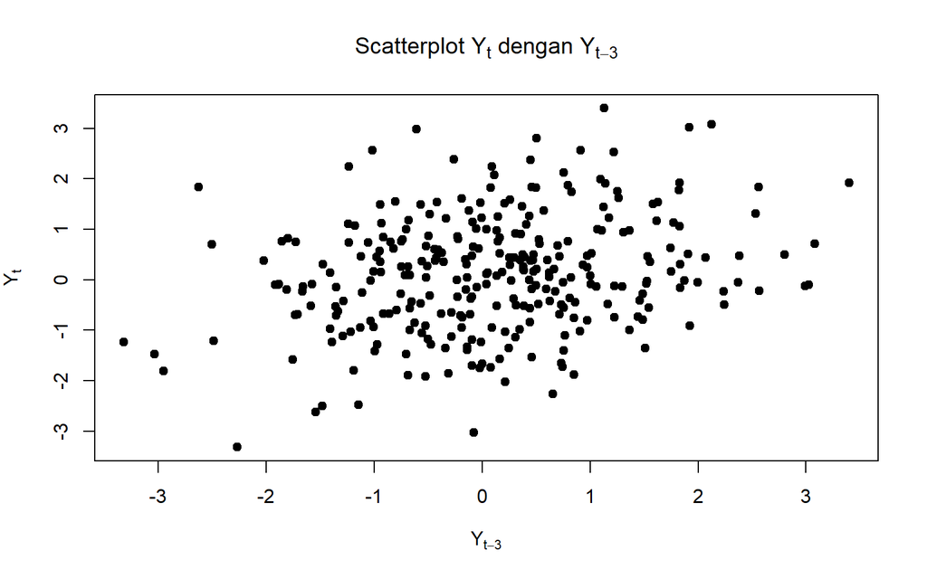

```r
lag3 <- data.frame(
  Yt = Y_arima[4:300],
  Yt_3 = Y_arima[1:297]
)

plot(
  lag3$Yt_3,
  lag3$Yt,
  main = expression(paste("Scatterplot ", Y[t], " dengan ", Y[t-3])),
  xlab = expression(Y[t-3]),
  ylab = expression(Y[t]),
  pch = 19
)
```

## Autokorelasi

### Autokorelasi Data Bangkitan

```r
acf_result <- acf(
  Y_arima,
  lag.max = 10,
  plot = FALSE
)

acf_empiris <- as.numeric(acf_result$acf)

data.frame(
  Lag = 0:(length(acf_empiris) - 1),
  Autokorelasi = acf_empiris
)
```

```
##    Lag Autokorelasi
## 1    0   0.53836537
## 2    1   0.38117471
## 3    2   0.24249327
## 4    3   0.09977753
## 5    4   0.09715433
## 6    5   0.04256081
## 7    6   0.07253935
## 8    7   0.07344132
## 9    8   0.03757027
## 10   9   0.01850053
```

```r
acf_empiris_1_3 <- acf_empiris[2:4]

data.frame(
  Lag = 1:3,
  Autokorelasi = acf_empiris_1_3
)
```

```
##   Lag Autokorelasi
## 1   1   0.38117471
## 2   2   0.24249327
## 3   3   0.09977753
```

### Autokorelasi Teoritis AR(2)

Untuk proses AR(2):
$$Y_t=\phi_1Y_{t-1}+\phi_2Y_{t-2}+\varepsilon_t$$

Autokorelasi teoritis AR(2) memenuhi persamaan Yule-Walker:
$$\rho_k=\phi_1\rho_{k-1}+\phi_2\rho_{k-2}$$

Untuk lag 1:
$$\rho_1=
\frac{\phi_1}{1-\phi_2}$$

Dengan $\phi_1=0.5$ dan $\phi_2=0.2$:
$$\rho_1=
\frac{0.5}{1-0.2}
=0.625$$

Untuk lag 2:
$$\rho_2=
\phi_1\rho_1+\phi_2\rho_0$$

karena $\rho_0=1$, maka:
$$\rho_2=
(0.5)(0.625)+(0.2)(1)
=0.5125$$

Untuk lag berikutnya digunakan:
$$\rho_k=\phi_1\rho_{k-1}+\phi_2\rho_{k-2}$$

```r
phi1 <- 0.5
phi2 <- 0.2

rho0 <- 1
rho1 <- phi1 / (1 - phi2)

rho2 <- phi1 * rho1 + phi2 * rho0
rho3 <- phi1 * rho2 + phi2 * rho1
rho4 <- phi1 * rho3 + phi2 * rho2

rho0
```

```
## [1] 1
```

```r
rho1
```

```
## [1] 0.625
```

```r
rho2
```

```
## [1] 0.5125
```

```r
rho3
```

```
## [1] 0.38125
```

```r
rho4
```

```
## [1] 0.293125
```

```r
acf_teoritis <- data.frame(
  Lag = 0:4,
  Autokorelasi = c(
    rho0,
    rho1,
    rho2,
    rho3,
    rho4
  )
)

acf_teoritis
```

```
##   Lag Autokorelasi
## 1   0     1.000000
## 2   1     0.625000
## 3   2     0.512500
## 4   3     0.381250
## 5   4     0.293125
```

### Perbandingan Autokorelasi Empiris dan Teoritis

```r
acf_obj <- acf(
  Y_arima,
  lag.max = 4,
  plot = FALSE
)

acf_empiris <- as.numeric(acf_obj$acf)[1:5]

perbandingan <- data.frame(
  Lag = 0:4,
  Empiris = acf_empiris,
  Teoritis = c(
    rho0,
    rho1,
    rho2,
    rho3,
    rho4
  )
)

perbandingan
```

```
##   Lag    Empiris Teoritis
## 1   0 0.53836537 1.000000
## 2   1 0.38117471 0.625000
## 3   2 0.24249327 0.512500
## 4   3 0.09977753 0.381250
## 5   4         NA 0.293125
```

## Kesimpulan

Proses yang dibangkitkan merupakan proses AR(2) dengan $\phi_1=0.5$ dan $\phi_2=0.2$. Berdasarkan plot time series, data berfluktuasi di sekitar rata-rata yang relatif konstan dan memiliki varians yang relatif stabil.

Untuk proses AR(2), ACF tidak terputus secara langsung setelah lag tertentu, tetapi cenderung meluruh secara bertahap. Sementara itu, PACF akan terputus setelah lag ke-2. Pola tersebut merupakan karakteristik dari proses AR(2).

Autokorelasi teoritis yang diperoleh adalah: $\rho_0=1$ $\rho_1=0.625$ $\rho_2=0.5125$ $\rho_3=0.38125$ $\rho_4=0.293125$

Nilai autokorelasi empiris dapat berbeda dengan nilai teoritis karena diperoleh dari sampel sebanyak 300 pengamatan.

# PROSES ARMA(2,2)

## Bangkitkan Data

Model ARMA(2,2) yang digunakan adalah:
$$Y_t =
\phi_1Y_{t-1}
+\phi_2Y_{t-2}
+\varepsilon_t
+\theta_1\varepsilon_{t-1}
+\theta_2\varepsilon_{t-2}$$

dengan:
$$\phi_1=0.5,\qquad
\phi_2=0.2$$

dan
$$\theta_1=0.4,\qquad
\theta_2=0.6$$

Jumlah data yang dibangkitkan adalah 300 pengamatan.

## Manual

```r
set.seed(123)

n <- 300
phi1 <- 0.5
phi2 <- 0.2
theta1 <- 0.4
theta2 <- 0.6
burn <- 100

epsilon <- rnorm(n + burn)

Y_full <- numeric(n + burn)

Y_full[1] <- epsilon[1]
Y_full[2] <- phi1 * Y_full[1] +
  epsilon[2] +
  theta1 * epsilon[1]

for (t in 3:(n + burn)) {

  Y_full[t] <-
    phi1 * Y_full[t-1] +
    phi2 * Y_full[t-2] +
    epsilon[t] +
    theta1 * epsilon[t-1] +
    theta2 * epsilon[t-2]
}
Y_manual <- Y_full[(burn + 1):(burn + n)]
head(Y_manual)
```

```
## [1]  1.20697955  0.56984589 -0.04386348 -0.20005169 -1.34744927 -1.34793569
```

## arima.sim

```r
set.seed(123)
Y_arima <- arima.sim(
  model = list(
    ar = c(phi1, phi2),
    ma = c(theta1, theta2)
  ),
  n = 300
)

head(Y_arima)
```

```
## Time Series:
## Start = 1
## End = 6
## Frequency = 1
## [1] -3.11187150 -2.78699743 -1.12528900 -0.87493596 -0.03472262  0.84062710
```

## Plot Time Series

### Data Manual

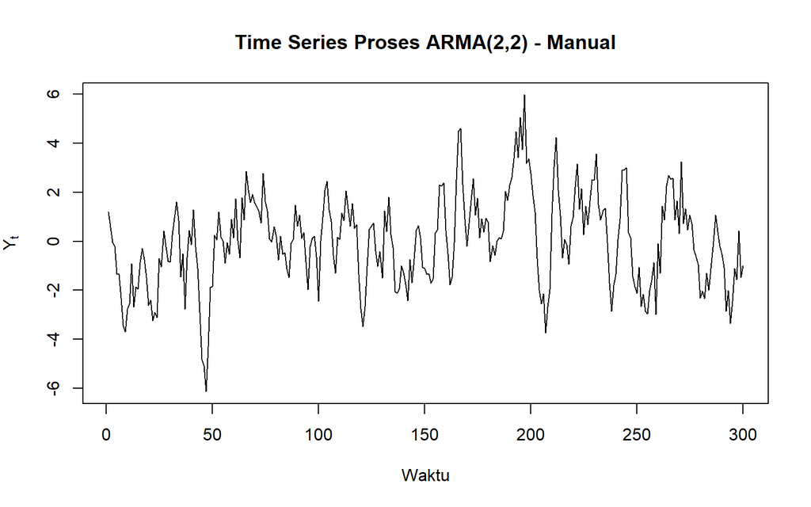

```r
plot(
  ts(Y_manual),
  main = "Time Series Proses ARMA(2,2) - Manual",
  xlab = "Waktu",
  ylab = expression(Y[t]),
  type = "l"
)
```

### Data arima.sim

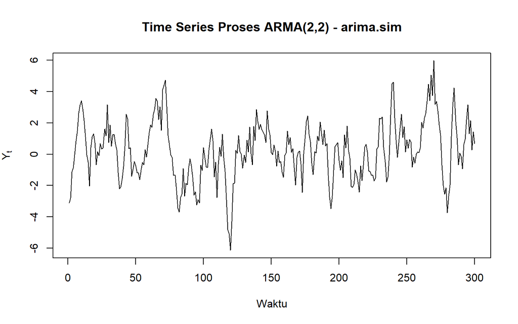

```r
plot(
  ts(Y_arima),
  main = "Time Series Proses ARMA(2,2) - arima.sim",
  xlab = "Waktu",
  ylab = expression(Y[t]),
  type = "l"
)
```

### Plot ACF

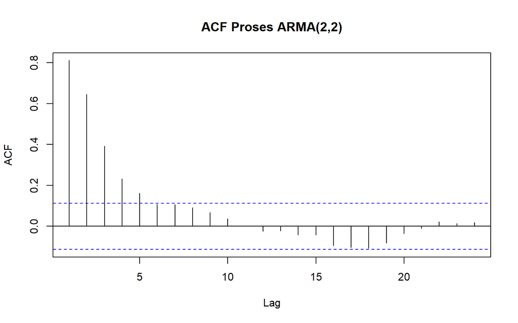

```r
acf(
  Y_arima,
  main = "ACF Proses ARMA(2,2)"
)
```

### Plot PACF

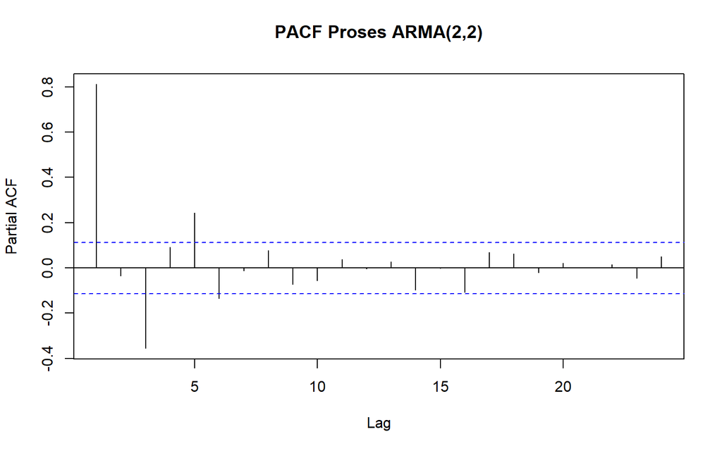

```r
pacf(
  Y_arima,
  main = "PACF Proses ARMA(2,2)"
)
```

### Plot EACF

```r
eacf(Y_arima)
```

```
## AR/MA
##   0 1 2 3 4 5 6 7 8 9 10 11 12 13
## 0 x x x x x o o o o o o  o  o  o
## 1 o x o o o x o o o o o  o  o  o
## 2 o x o o o x o o o o o  o  o  o
## 3 x x o x o x o o o o o  o  o  o
## 4 x x o x o x o o o o o  o  o  o
## 5 x x o x x o o o o o o  o  o  o
## 6 x x o x x o o o o o o  o  o  o
## 7 x x x x x o o o o o o  o  o  o
```

## Identifikasi Stasioneritas

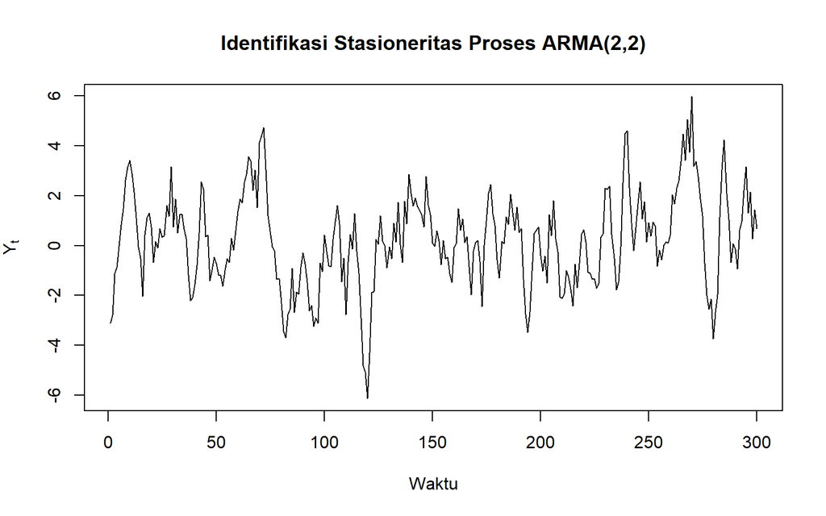

```r
plot(
  ts(Y_arima),
  main = "Identifikasi Stasioneritas Proses ARMA(2,2)",
  xlab = "Waktu",
  ylab = expression(Y[t]),
  type = "l"
)
```

```r
adf.test(Y_arima)
```

```
##
##  Augmented Dickey-Fuller Test
##
## data:  Y_arima
## Dickey-Fuller = -4.9605, Lag order = 6, p-value = 0.01
## alternative hypothesis: stationary
```

Berdasarkan visual dan uji yang kita lakukan, dapat disimpulkan bahwa datanya stasioner.

## Scatter Plot

### Scatterplot $Y_t$ dengan $Y_{t-1}$

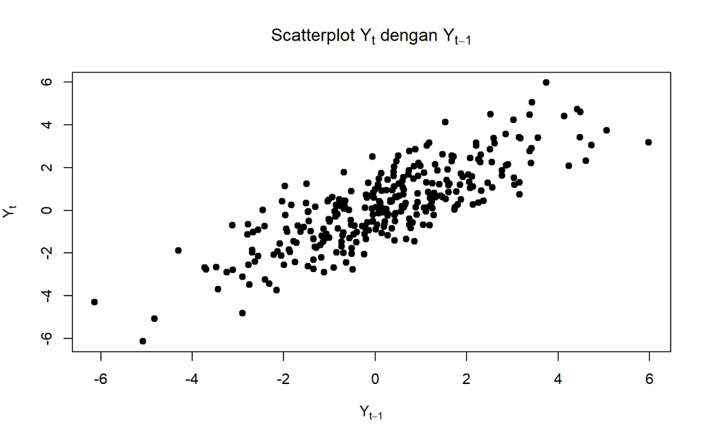

```r
lag1 <- data.frame(
  Yt = Y_arima[2:300],
  Yt_1 = Y_arima[1:299]
)

plot(
  lag1$Yt_1,
  lag1$Yt,
  main = expression(
    paste("Scatterplot ", Y[t],
          " dengan ", Y[t-1])
  ),
  xlab = expression(Y[t-1]),
  ylab = expression(Y[t]),
  pch = 19
)
```

### Scatterplot $Y_t$ dengan $Y_{t-2}$

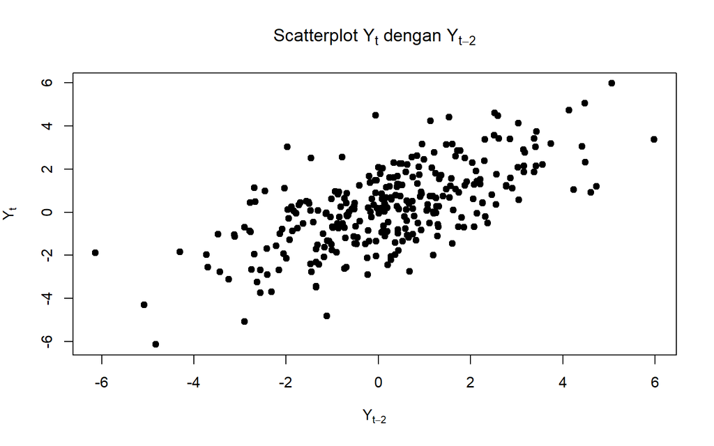

```r
lag2 <- data.frame(
  Yt = Y_arima[3:300],
  Yt_2 = Y_arima[1:298]
)

plot(
  lag2$Yt_2,
  lag2$Yt,
  main = expression(
    paste("Scatterplot ", Y[t],
          " dengan ", Y[t-2])
  ),
  xlab = expression(Y[t-2]),
  ylab = expression(Y[t]),
  pch = 19
)
```

### Scatterplot $Y_t$ dengan $Y_{t-3}$

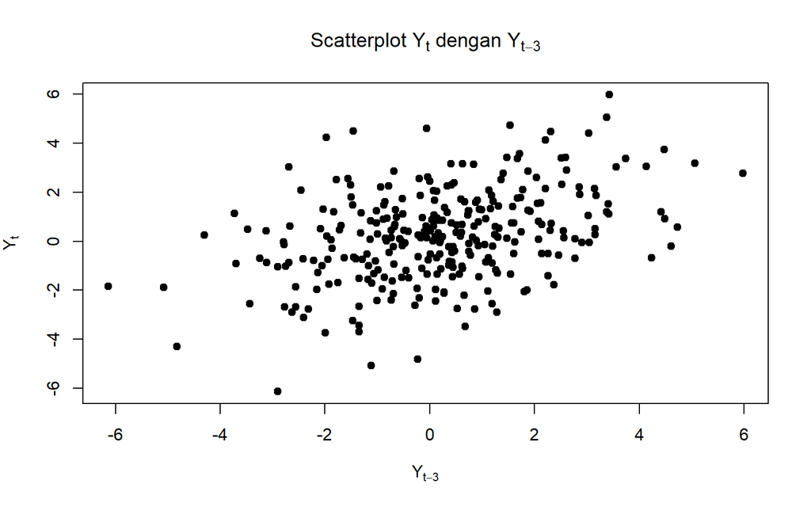

```r
lag3 <- data.frame(
  Yt = Y_arima[4:300],
  Yt_3 = Y_arima[1:297]
)

plot(
  lag3$Yt_3,
  lag3$Yt,
  main = expression(
    paste("Scatterplot ", Y[t],
          " dengan ", Y[t-3])
  ),
  xlab = expression(Y[t-3]),
  ylab = expression(Y[t]),
  pch = 19
)
```

## Autokorelasi

### Autokorelasi Data Bangkitan

```r
acf_result <- acf(
  Y_arima,
  lag.max = 10,
  plot = FALSE
)

acf_empiris <- as.numeric(acf_result$acf)

data.frame(
  Lag = 0:(length(acf_empiris) - 1),
  Autokorelasi = acf_empiris
)
```

```
##    Lag Autokorelasi
## 1    0   0.81078914
## 2    1   0.64540289
## 3    2   0.39166833
## 4    3   0.23298922
## 5    4   0.16167096
## 6    5   0.10753738
## 7    6   0.10613054
## 8    7   0.09157156
## 9    8   0.06809308
## 10   9   0.03690698
```

```r
acf_empiris_1_3 <- acf_empiris[2:4]

data.frame(
  Lag = 1:3,
  Autokorelasi = acf_empiris_1_3
)
```

```
##   Lag Autokorelasi
## 1   1    0.6454029
## 2   2    0.3916683
## 3   3    0.2329892
```

### Autokorelasi Teoritis ARMA(2,2)

Untuk proses ARMA(2,2):
$$Y_t =
\phi_1Y_{t-1}
+\phi_2Y_{t-2}
+\varepsilon_t
+\theta_1\varepsilon_{t-1}
+\theta_2\varepsilon_{t-2}$$

Autokorelasi teoritis ARMA(2,2) tidak dapat dihitung hanya menggunakan rumus sederhana seperti pada MA(2). Nilai autokorelasi diperoleh menggunakan persamaan Yule-Walker. Untuk memperoleh nilai autokorelasi teoritis secara langsung di R, digunakan fungsi `ARMAacf()`.

```r
acf_teoritis <- ARMAacf(
  ar = c(phi1, phi2),
  ma = c(theta1, theta2),
  lag.max = 10
)

data.frame(
  Lag = 0:10,
  Autokorelasi = acf_teoritis
)
```

```
##    Lag Autokorelasi
## 0    0   1.00000000
## 1    1   0.85919932
## 2    2   0.74919080
## 3    3   0.54643526
## 4    4   0.42305579
## 5    5   0.32081495
## 6    6   0.24501863
## 7    7   0.18667231
## 8    8   0.14233988
## 9    9   0.10850440
## 10  10   0.08272018
```

### Autokorelasi Teoritis Lag 1, 2, dan 3

```r
rho0 <- acf_teoritis[1]
rho1 <- acf_teoritis[2]
rho2 <- acf_teoritis[3]
rho3 <- acf_teoritis[4]

data.frame(
  Lag = 0:3,
  Autokorelasi_Teoritis =
    c(rho0, rho1, rho2, rho3)
)
```

```
##   Lag Autokorelasi_Teoritis
## 0   0             1.0000000
## 1   1             0.8591993
## 2   2             0.7491908
## 3   3             0.5464353
```

### Perbandingan Autokorelasi Empiris dan Teoritis

```r
acf_empiris <- as.numeric(
  acf(
    Y_arima,
    lag.max = 3,
    plot = FALSE
  )$acf
)

acf_teoritis_3 <- ARMAacf(
  ar = c(phi1, phi2),
  ma = c(theta1, theta2),
  lag.max = 3
)

if (length(acf_teoritis_3) == 3) {
  acf_teoritis_3 <- c(1, acf_teoritis_3)
}

acf_empiris <- acf_empiris[1:4]
acf_teoritis_3 <- acf_teoritis_3[1:4]

perbandingan <- data.frame(
  Lag = 0:3,
  Empiris = acf_empiris,
  Teoritis = acf_teoritis_3
)

perbandingan
```

```
##   Lag   Empiris  Teoritis
## 0   0 0.8107891 1.0000000
## 1   1 0.6454029 0.8591993
## 2   2 0.3916683 0.7491908
## 3   3        NA 0.5464353
```

## Kesimpulan

Proses yang dibangkitkan merupakan proses ARMA(2,2) dengan parameter:
$$\phi_1=0.5,\quad
\phi_2=0.2,\quad
\theta_1=0.4,\quad
\theta_2=0.6.$$

Berdasarkan plot time series, data dapat diamati berfluktuasi di sekitar rata-rata yang relatif konstan dengan varians yang relatif stabil.

Proses ARMA(2,2) bersifat stasioner apabila bagian AR memenuhi kondisi stasioner. Untuk model ini, akar dari persamaan karakteristik berada di luar lingkaran satu sehingga proses AR memenuhi kondisi stasioner.

Pada proses ARMA(2,2), ACF dan PACF umumnya sama-sama menunjukkan pola peluruhan (*tailing off*), sehingga berbeda dengan MA(2) yang ACF-nya terputus setelah lag ke-2 dan AR(2) yang PACF-nya terputus setelah lag ke-2.

Nilai autokorelasi empiris diperoleh dari data hasil pembangkitan, sedangkan autokorelasi teoritis diperoleh berdasarkan parameter AR dan MA. Perbedaan antara keduanya dapat terjadi karena data yang digunakan merupakan sampel terbatas sebanyak 300 pengamatan.